## Preparing data (logarithmic transformation of explainable variable, division into training and test data set)

## Scoring function and function to plot permutational variable importance

# 1) Model XGB

```
XGB   results:
training rmse: 1.9896428769333043
training r2: 0.480823263320056
training mae: 1.4731932200056865
test rmse: 2.1815080002619207
test r2: 0.36767723504652927
test mae: 1.6220293519004516
```

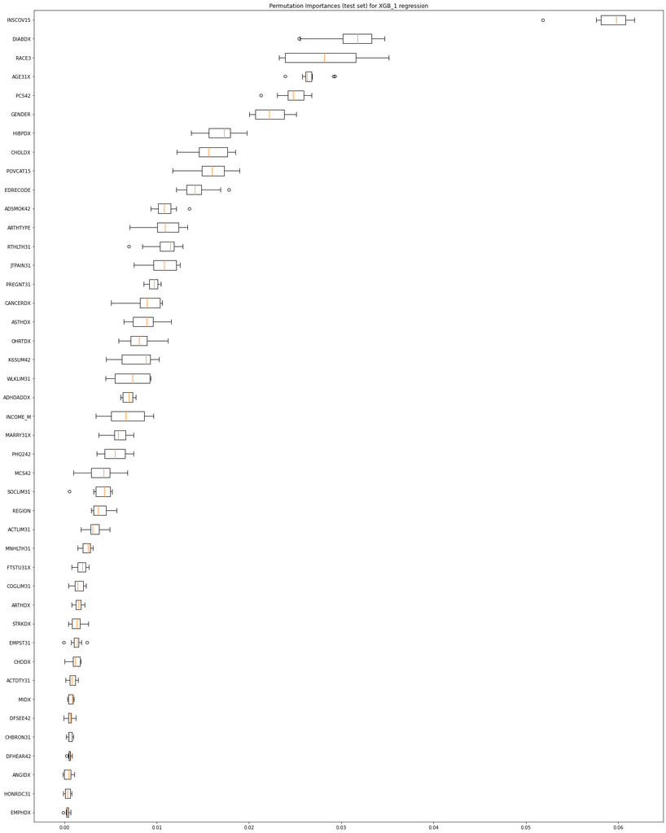

## 2) Model XGB with additional data transformations

### Model's additional data transformations: one hot encoding, minmax scaling

```
Categorical variables to one hot encode:
 ['HIBPDX', 'CHDDX', 'ANGIDX', 'MIDX', 'OHRTDX', 'STRKDX', 'EMPHDX', 'CHBRON31', 'CHOLDX', 'CANCERDX', 'DIABDX', 'JTPAIN31', 'ARTHDX', 'ASTHDX', 'ADHDADDX', 'PREGNT31', 'WLKLIM31', 'ACTLIM31', 'SOCLIM31', 'COGLIM31', 'DFHEAR42', 'DFSEE42', 'ADSMOK42']
```

```
XGB   results:
training rmse: 2.004730414294387
training r2: 0.4729195356270913
training mae: 1.4850506374315113
test rmse: 2.166275261786406
test r2: 0.3764769999538592
test mae: 1.6102627248009824
```

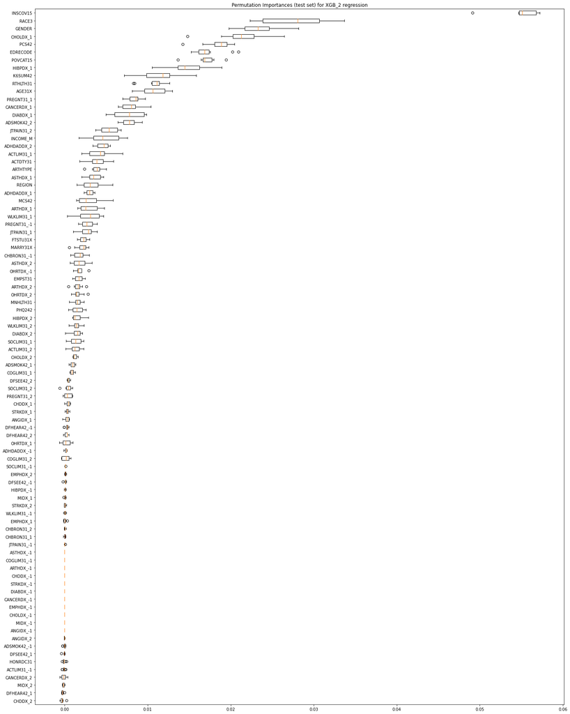

## 3) Model XGB with additional data transformations

### Model's additional data transformations: one hot encoding, minmax scaling, addition of a column (# of tested positive)

```
XGB   results:
training rmse: 2.001923531369142
training r2: 0.47439446455704903
training mae: 1.4835221534450043
test rmse: 2.1641499330064535
test r2: 0.37769987437695984
test mae: 1.6054573155491896
```

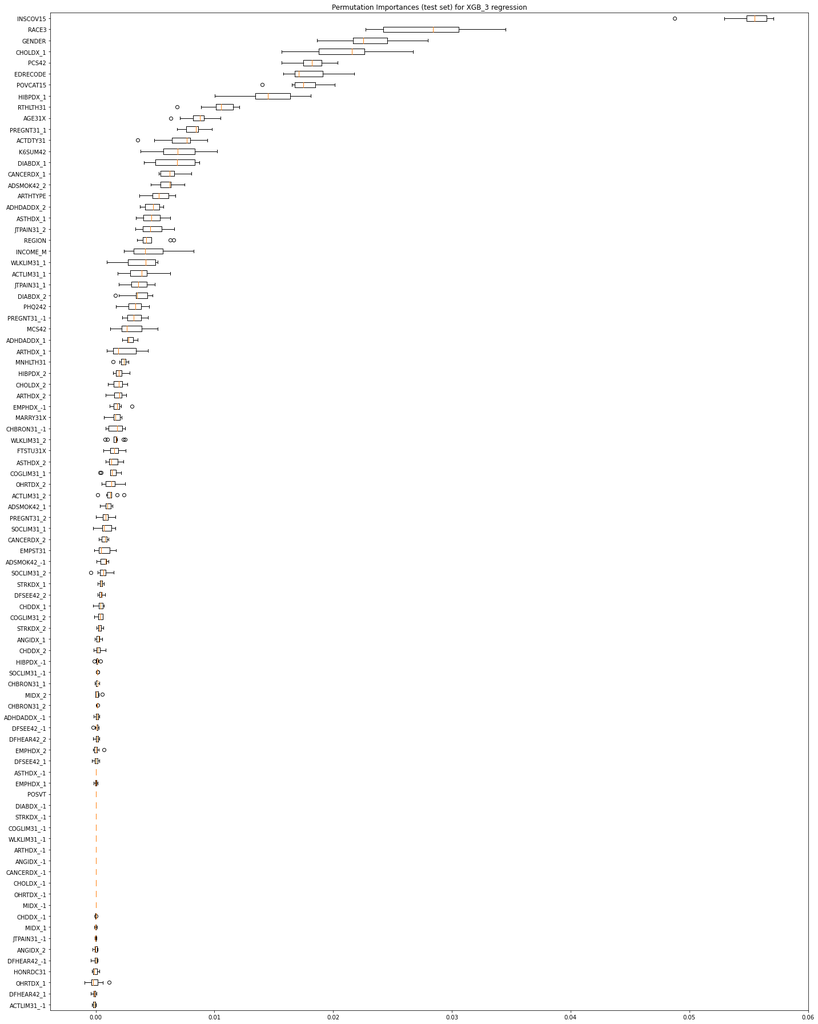

## 4) Model Random Forrest

```
Random Forrest   results:
training rmse: 1.7726968555568756
training r2: 0.5878703026796824
training mae: 1.3053567063441656
test rmse: 2.2009505281433546
test r2: 0.35635594953464256
test mae: 1.6319088794583885
```

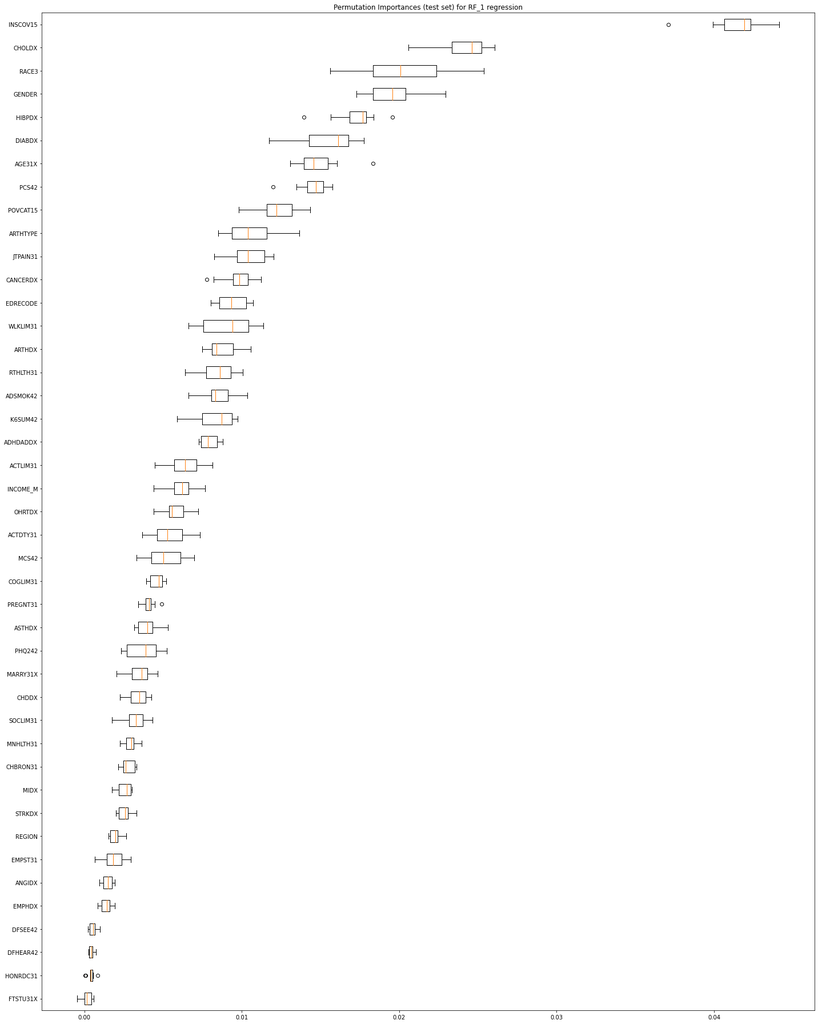

## 5) Model Random Forrest

### Model's additional data transformations: one extra column

```
Random Forrest   results:
training rmse: 1.7406618476467186
training r2: 0.6026311840255166
training mae: 1.282522908124817
test rmse: 2.188991026223282
test r2: 0.363331797851958
test mae: 1.627112620552408
```

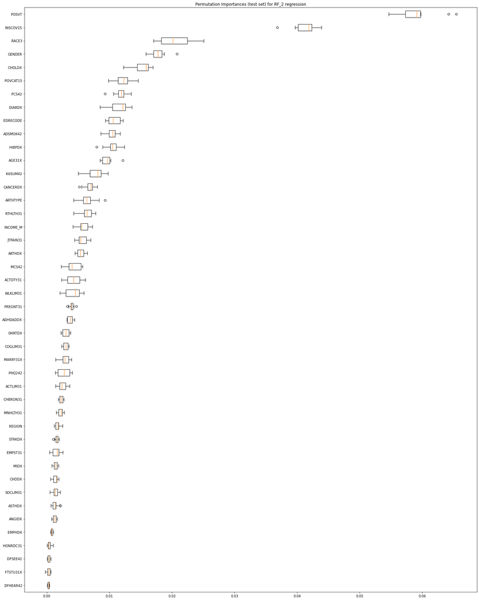

## 6) Linear model

### Model's additional data transformations: addition of a column (# of tested positive), minmax scaling

```
Ridge Regression results:
training rmse: 2.266885671580016
training r2: 0.3260554024765099
training mae: 1.717582420692549
test rmse: 2.2507713632601125
test r2: 0.32688702912191125
test mae: 1.6984020041883288
```

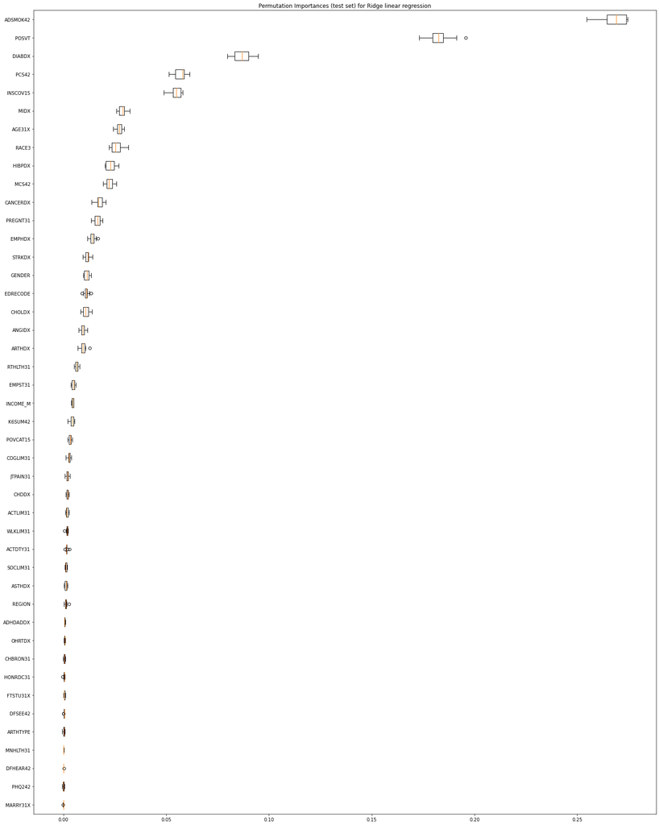

## The results

### Comments and results:

Medical Expenditure Panel Survey (MEPS) data set about medical health and its costs. The explainable variable is called HEALTHEXP and describes the cost of the patient’s health expenses. For this homework, data primarily was only divided into the training and test data set. Due the long tail of the HEALTHEXP it was transformed with the logarithm of a base 3 (easier to explain than with the natural logarithm). Following models were trained: 1) XGB 2) XGB with one hot encoding and minmax scaling 3) XGB with one hot encoding, minmax scaling and creation of additional column 4) Random Forest 5) Random Forest with the additional column 6) Linear model with minmax scaling and creation of additional column

One hot encoding concerned the categorical variables : 'HIBPDX', 'CHDDX', 'ANGIDX', 'MIDX', 'OHRTDX', 'STRKDX', 'EMPHDX', 'CHBRON31', 'CHOLDX', 'CANCERDX', 'DIABDX', 'JTPAIN31', 'ARTHDX', 'ASTHDX', 'ADHDADDX', 'PREGNT31', 'WLKLIM31', 'ACTLIM31', 'SOCLIM31', 'COGLIM31', 'DFHEAR42', 'DFSEE42', 'ADSMOK42'. This variables describe if the patient has given symptom/disease/condition. Each of them has three possibles values -1 (inapplicable), 1 (yes) or 2 (no).

Minmax scaling concerned the numerical variables: 'RTHLTH31', 'MNHLTH31', 'POVCAT15'. RTHLTH31 encodes the perceived health status. MNHLTH31 describes the perceived mental health status. For both of variables scale goes from -1 to 5, where 5 is poor. POVCAT15 encoded the income. Scale goes from 1 to 5, where 1 is poor and 5 is high income.

Additional column creation is the transformations that creates an additional column which counts how many times given patient was tested positive for any symptom/disease/condition. The column was called ‘POSVT’.

Regarding XGB typ models (1,2 and 3) the test results (r^2) were the best for model 3 (test r2: 0.377, mae: 1.605, rmse: 2.164). Model 2 had slightly worse results than model 3 (test r2: 0.376, mae: 1.61, rmse: 2.166). Model 1 had the worst results (test r2: 0.367, mae: 1.622, rmse: 2.181). Model 2 and 3 have really close results. 3 most important features:

- model 1: INSCOV15, DIABDX, RACE3
- model 2: INSCOV15, RACE3, GENDER
- model 3: INSCOV15, RACE3, GENDER Model 2 and 3 had 7 the most important features of the same variables in the same order. It interesting to notice that distributions of each of the variables differs in each model, especially in the most important one (INSCOV15). INSCOV15 is categorical variables which tells if patient has a insurance (private or public). DIABDX is also a categorical variable which tells if patients has been diagnosed with diabetes.  
  RACE3 describes the race (0 or 1).

- model 4: INSCOV15, CHOLDX, RACE3
- model 5: POSVT, INSCOV15, RACE3 Models has in common two the most important variables.

## The results

### Comments and results:

Medical Expenditure Panel Survey (MEPS) data set about medical health and its costs. There are 45 variables. The explainable variable is called HEALTHEXP and describes the cost of the patient’s health expenses. For this homework, data primarily was only divided into the training and test data set. Due the long tail of the HEALTHEXP it was transformed with the logarithm of a base 3 (easier to explain than with the natural logarithm). Following models were trained: 1) XGB 2) XGB with one hot encoding and minmax scaling 3) XGB with one hot encoding, minmax scaling and creation of additional column 4) Random Forest 5) Random Forest with the additional column 6) Linear model with minmax scaling and creation of additional column

One hot encoding concerned the categorical variables : 'HIBPDX', 'CHDDX', 'ANGIDX', 'MIDX', 'OHRTDX', 'STRKDX', 'EMPHDX', 'CHBRON31', 'CHOLDX', 'CANCERDX', 'DIABDX', 'JTPAIN31', 'ARTHDX', 'ASTHDX', 'ADHDADDX', 'PREGNT31', 'WLKLIM31', 'ACTLIM31', 'SOCLIM31', 'COGLIM31', 'DFHEAR42', 'DFSEE42', 'ADSMOK42'. This variables describe if the patient has given symptom/disease/condition. Each of them has three possibles values -1 (inapplicable), 1 (yes) or 2 (no).

Minmax scaling concerned the numerical variables: 'RTHLTH31', 'MNHLTH31', 'POVCAT15'. RTHLTH31 encodes the perceived health status. MNHLTH31 describes the perceived mental health status. For both of variables scale goes from -1 to 5, where 5 is poor. POVCAT15 encoded the income. Scale goes from 1 to 5, where 1 is poor and 5 is high income.

Additional column creation is the transformations that creates an additional column which counts how many times given patient was tested positive for any symptom/disease/condition. The column was called ‘POSVT’.

Regarding XGB typ models (1,2 and 3), model 2 and 3 have really close results. The test results (r^2) were the best for model 3 (test r2: 0.377, mae: 1.605, rmse: 2.164). Model 2 had slightly worse results (r^2) than model 3 (test r2: 0.376, mae: 1.61, rmse: 2.166). Model 1 had the worst results (test r2: 0.367, mae: 1.622, rmse: 2.181). 3 most important features:

- model 1: INSCOV15, DIABDX, RACE3
- model 2: INSCOV15, RACE3, GENDER
- model 3: INSCOV15, RACE3, GENDER

Model 2 and 3 had 7 the most important features of the same variables in the same order. It interesting to notice that distributions of each of the variables differs in each model, especially in the most important one (INSCOV15). INSCOV15 is categorical variables which tells if patient has a insurance (private, public or none). DIABDX is also a categorical variable which tells if patients has been diagnosed with diabetes.  
RACE3 describes the race (0 or 1).

Regarding the random forest models (4 and 5), model 5 had better scores (test r^2: 0.363, mae: 1.627, rmse: 2.188) than model 4 (test r^2: 0.356, mae: 1.631, rmse: 2.2). 3 most important features:

- model 4: INSCOV15, CHOLDX, RACE3
- model 5: POSVT, INSCOV15, RACE3

Random Forest models as XGB had INSCOV15 as one of the most important variables. Also the distribution of this variables differs. POSVT is a variable that was created and counts the number of patients positive results. It is the most important for random forest model 5 but for model 3 (XGB) this variable is 20th from the bottom (so completely opposite).

Last of investigated models was a linear model. Test results were worse than for any other model (test r^2: 0.326, mae: 1.698, rmse: 2.25). 3 most important features:

- ADSMOKE42
- POSVT
- DIABDX